# La construcción de la variable Ingreso en la Casen 2017

Ingresos de los hogares versus el de las personas

CC

DataIntelligence

19-02-2021

Abstract

Hemos podido descomponer los ingresos de los **hogares** en 5 categorías que se van construyendo simplemente sumando algunas anteriores. Y las hemos propuesto como las variables necesarias y suficientes para la generación de tablas de contingencia (ttcc) de un conjunto de variables categóricas de la Casen (sexo, alfabetismo, etnia) sobre el promedio de la variable de ingreso de la categoría construída. Surge un problema cuando seleccionamos las variables de ingreso a nivel de hogares, y es que no podemos clasificar su promedio dentro de ttcc. Por ejemplo, no podríamos agrupar por sexo, si el valor del ingreso es considerado a nivel de hogar. Debemos encontrar las variables que identifiquen los ingresos de las personas. En éste trabajo iremos comparando los 5 ingresos propuestos entre personas y hogares para corroborar que las variables que hemos seleccionado a nivel de las personas sean correctas ahondando un poco más dentro de la lógica de construcción de los ingresos de la Casen.

## Índice

### 1 Introducción

### 2 La relación entre los ingresos totales del hogar y el de las personas (yototcor-yototcorh)

### 3 La relación entre los ingresos de la ocupación principal versus los ingresos del trabajo (yoprcorh e ytrabajocorh)

### 4 El ingreso autónomo

### 5 El ingreso monetario

### 6 El alquiler imputado

### 7 Conclusiones

## 1 Introducción

Con [un cálculo básico](https://rpubs.com/dataintelligence/la_construccion_del_ingreso) propusimos las variables de Ingreso en la Casen que deberíamos considerar y demostramos su descomposición como sumas simples. Pero lo hicimos a nivel de hogares. Debemos hacerlo a nivel de las personas para construir tablas de contigencia con sentido.

Ya tenemos una propuesta:

| año |  |  |  |  |
| --- | --- | --- | --- | --- |
| 2017 | ytotcor | yautcor | ytrabajocor | yoprcor |
| 2015 | ytotcor | yautcor | ytrabajocor | yoprcor |
| 2013 | ytotcor | yautcor | ytrabajocor | yoprcor |
| 2011 | ytotaj | yautaj | ytrabaj | yopraj |
| 2009 | ytotaj | yautaj | ytrabaj | yopraj |
| 2006 | ytotaj | yautaj | ytrabaj | yopraj |

Si el cálculo de la descomposición en forma de sumas simples es correcta para el año 2017, si estamos hablando de las mismas variables, es correcto para todos los años. Tenemos un trabajo que lo asegura.

Por lo mismo, el análisis que hacemos en éste documento es extensible al rango 2006-2017.

Iremos comparando las variables **ytotcor**, **yautcor**, **ytrabajocor** e **yoprcor** entre el nivel de personas y hogares e iremos verificando ciertos supuestos básicos que deben subyacer a las construcción de los ingresos.

Originalmente propusimos:

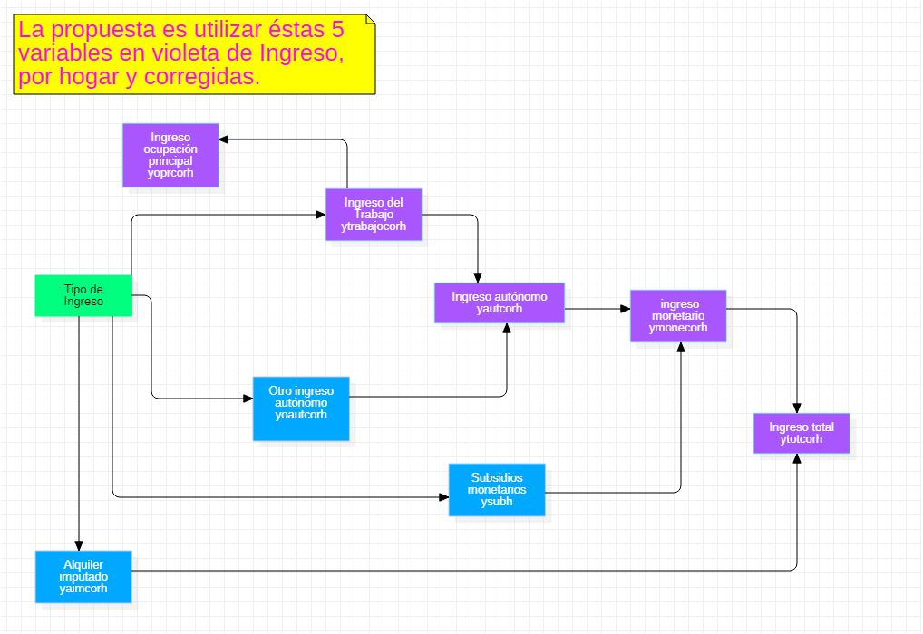

Consideraciones:

1. Tomamos siempre los ingresos corregidos (cor).
2. Haremos el análisis sobre los ingresos del hogar, luego sobre el de las personas y compararemos.

## 2 La relación entre los ingresos totales del hogar y el de las personas (ytotcorh-ytotcor)

### 1.1 La pregunta

#### La variable de ingresos que agrupa a todas las demás es **ytotcor**, que suma el ingreso monetario más el alquiler imputado. Ésta variable existe tanto para hogares como para personas. Queremos saber si este valor es para los hogares el promedio del de las personas del hogar.

```r
# Leemos la base de datos
dataset_2017 <- readRDS(file = "casen_2017_c.rds")
```

Compararemos ambos resultados en la Casen del 2017.

### 1.1 ytotcorh: Los ingresos totales de las personas en los hogares:

```r
head(dataset_2017$ytotcorh,50)
```

```
##  [1]  591667  591667 1267932 1267932  420000  420000  420000  829868  829868
## [10]  829868  829868  829868 1223990 1223990 1223990 1291133 1291133 1291133
## [19]  444167  885833  993000  800000  800000 5172105 5172105 1020000 1020000
## [28]  905000  905000 1771754 1771754  750000 2501561 2501561 2501561  544945
## [37]  544945 1412500 1412500 1248766 1248766 1248766 1248766 1248766  424932
## [46] 2850000 2850000 2850000 1433364 1433364
```

### 1.2 ytotcor: Ingresos totales de las personas:

```r
head(dataset_2017$ytotcor,50)
```

```
##  [1]  272000  159667  786932  301000  220000  200000      NA  296634   11052
## [10]  500000      NA   22182  573990  400000      NA  250000  860833      NA
## [19]  264167  735833  843000  500000      NA 3150000 2022105  550000  170000
## [28]  500000  405000  130000 1191754  400000  404646  932629  814286  109578
## [37]  135367  962500      NA  595000  212675  180000   11091      NA  144932
## [46] 1250000 1000000      NA 1232464      NA
```

#### ¿Es el ingreso total de los hogares el promedio del de los integrantes?

Si fuera así, el ingreso total del hogar siempre seria menor o igual al ingreso total personal:
$$ytotcor >= ytotcorh$$

pues en el hogar pueden existir miembros que no trabajen.

o bien en el caso de un hogar de dos personas que ganen aproximadamente los mismo:
$$ytotcor \approx ytotcorh$$

#### Observamos que el ingreso total de los hogares es mucho mayor al de las personas.

Si no son el promedio sospechamos que es la suma total, con lo que se cumpliria que:
$$ytotcor <<= ytotcorh$$

Para verificar lo anterior calculemos los promedios:

```r
c <- as.data.frame(dataset_2017$ytotcor)
mean(c, na.rm=TRUE)
```

```
## [1] 415297.9
```

```r
d <- as.data.frame(dataset_2017$ytotcorh)
mean(d, na.rm=TRUE)
```

```
## [1] 1164452
```

Verifiquémoslo de otra forma y veamos cuántos son los registros en los que ytotcor difiere de ytotcorh:

```r
a <- dataset_2017$ytotcorh[!(dataset_2017$ytotcorh %in% dataset_2017$ytotcor)]
length(a)
```

```
## [1] 132617
```

difieren 132617 registros.

#### Concluímos que los ingresos totales son la suma de todos los ingresos de los integrantes del hogar, pues $$ytotcor <<= ytotcorh$$

## 3 La relación entre los ingresos de la ocupación principal versus los ingresos del trabajo (yoprcorh e ytrabajocorh)

### 3.1 Las preguntas

1. Queremos saber si el ingreso de la ocupación principal de los hogares es menor al ingreso del trabajo de los hogares:

Si es cierto, siempre deberia cumplirse que:
$$yoprcorh < ytrabajocorh$$

2. Queremos saber si ingreso del trabajo de la ocupación principal personal es diferente al ingreso de la ocupación principal del hogar.
3. También queremos saber si son menores los ingresos del trabajo de personas que el de los hogares. Especulamos que el ingreso del trabajo del hogar debiese ser mayor y la suma del personal.

Si lo anterior es cierto, siempre debería cumplirse que:
$$ytrabajocor <= ytrabajocorh$$

### 3.2 Ingresos de la ocupación principal en los hogares e ingresos del trabajo en los hogares

Los ingresos de la ocupación principal de los hogares:

```r
head(dataset_2017$yoprcorh,50)
```

```
##  [1]  160000  150000  600000      NA      NA  200000      NA  280000      NA
## [10]  500000      NA      NA  480000      NA      NA  150000  750000      NA
## [19]  260000  450000      NA      NA      NA 2000000 2000000      NA      NA
## [28]  350000  355000      NA 1191754      NA      NA  932629  814286      NA
## [37]      NA      NA      NA  340000      NA      NA      NA      NA      NA
## [46] 1000000 1000000      NA  752750      NA
```

Los ingresos del trabajo de los hogares:

```r
head(dataset_2017$ytrabajocorh,50)
```

```
##  [1]  319667  319667  772000  772000  200000  200000  200000  780000  780000
## [10]  780000  780000  780000  953500  953500  953500 1110833 1110833 1110833
## [19]  264167  733333       0       0       0 4000000 4000000       0       0
## [28]  905000  905000 1191754 1191754       0 1746915 1746915 1746915       0
## [37]       0       0       0  345000  345000  345000  345000  345000       0
## [46] 2000000 2000000 2000000  752750  752750
```

Efectivamente, yoprcorh es una parte del ingreso del trabajo del hogar: ytrabajocorh, pero no tiene sentido que el trabajo de la ocupación principal personal sea diferente al ingreso de la ocupación principal del hogar, porque generalmente es una persona la que trabaja en un núcleo, y si fueran dos, de todas formas sería una la que tendría una ocupación principal en el hogar que también sería su ingreso personal principal. Corroboremos esto en la Casen:

### 3.3 Ingresos de la ocupación principal personal y de los hogares

Especulamos que los valores de éstos campos, debiesen ser los mismos.

```r
head(dataset_2017$yoprcor,50)
```

```
##  [1]  160000  150000  600000      NA      NA  200000      NA  280000      NA
## [10]  500000      NA      NA  480000      NA      NA  150000  750000      NA
## [19]  260000  450000      NA      NA      NA 2000000 2000000      NA      NA
## [28]  350000  355000      NA 1191754      NA      NA  932629  814286      NA
## [37]      NA      NA      NA  340000      NA      NA      NA      NA      NA
## [46] 1000000 1000000      NA  752750      NA
```

```r
head(dataset_2017$yoprcorh,50)
```

```
##  [1]  160000  150000  600000      NA      NA  200000      NA  280000      NA
## [10]  500000      NA      NA  480000      NA      NA  150000  750000      NA
## [19]  260000  450000      NA      NA      NA 2000000 2000000      NA      NA
## [28]  350000  355000      NA 1191754      NA      NA  932629  814286      NA
## [37]      NA      NA      NA  340000      NA      NA      NA      NA      NA
## [46] 1000000 1000000      NA  752750      NA
```

Al parecer ambos campos poseen la misma información.

```r
a <- dataset_2017$yoprcor[!(dataset_2017$yoprcor %in% dataset_2017$yoprcorh)]
a
```

```
## numeric(0)
```

En esta columna, la Casen posee información redundante.

### 3.4 Ingresos del trabajo: personas y hogares

¿Son menores los ingresos del trabajo de personas que el de sus hogares?

Si lo anterior es cierto, siempre deberia cumplirse que:
$$ytrabajocor <= ytrabajocorh$$

```r
a <- dataset_2017$ytrabajocorh[!(dataset_2017$ytrabajocorh %in% dataset_2017$ytrabajocor)]
head(a,10)
```

```
##  [1]  953500  953500  953500       0       0       0       0       0       0
## [10] 1746915
```

Si. Los tres primeros registros y el decimo son diferentes.

Ingresos del trabajo de los hogares

```r
head(dataset_2017$ytrabajocorh,50)
```

```
##  [1]  319667  319667  772000  772000  200000  200000  200000  780000  780000
## [10]  780000  780000  780000  953500  953500  953500 1110833 1110833 1110833
## [19]  264167  733333       0       0       0 4000000 4000000       0       0
## [28]  905000  905000 1191754 1191754       0 1746915 1746915 1746915       0
## [37]       0       0       0  345000  345000  345000  345000  345000       0
## [46] 2000000 2000000 2000000  752750  752750
```

Ingresos del trabajo de las personas

```r
head(dataset_2017$ytrabajocor,50)
```

```
##  [1]  160000  159667  772000      NA      NA  200000      NA  280000      NA
## [10]  500000      NA      NA  553500  400000      NA  250000  860833      NA
## [19]  264167  733333      NA      NA      NA 2000000 2000000      NA      NA
## [28]  500000  405000      NA 1191754      NA      NA  932629  814286      NA
## [37]      NA      NA      NA  345000      NA      NA      NA      NA      NA
## [46] 1000000 1000000      NA  752750      NA
```

y como es de esperar:

$$ytrabajocor <<= ytrabajocorh$$
Concluímos que el ingreso del trabajo de las personas en el hogar también (como ocurre en el caso de los ingresos totales) es la suma del ingreso del trabajo de las personas del hogar (y no como se podría pensar, el promedio).

## 4 El ingreso autónomo yautcorh (sin ayuda estatal)

Son los ingresos que generan las personas por su cuenta, excluyendo todo tipo de ayuda estatal.

Consiste en la suma del Ingreso del trabajo y otros Ingresos autónomos

Tiene sentido que el ingreso autónomo corregido de los hogares sea mayor al personal.

```r
head(dataset_2017$yautcorh,50)
```

```
##  [1]  428667  428667  992000  992000  420000  420000  420000  780000  780000
## [10]  780000  780000  780000  953500  953500  953500 1110833 1110833 1110833
## [19]  264167  735833  843000  500000  500000 5150000 5150000  720000  720000
## [28]  905000  905000 1321754 1321754  400000 2046915 2046915 2046915       0
## [37]       0  962500  962500  975000  975000  975000  975000  975000  140000
## [46] 2250000 2250000 2250000 1232464 1232464
```

```r
head(dataset_2017$yautcor,50)
```

```
##  [1]  269000  159667  772000  220000  220000  200000      NA  280000      NA
## [10]  500000      NA      NA  553500  400000      NA  250000  860833      NA
## [19]  264167  735833  843000  500000      NA 3150000 2000000  550000  170000
## [28]  500000  405000  130000 1191754  400000  300000  932629  814286      NA
## [37]      NA  962500      NA  595000  200000  180000      NA      NA  140000
## [46] 1250000 1000000      NA 1232464      NA
```

## 5 El ingreso monetario ymonecor (con ayuda estatal)

Los ingresos monetarios son coloquialmente toda la plata que en definitiva llega al bolsillo de las personas o de los hogares.

Los ingresos monetarios son la suma de:

1. los subsidios monetarios.
2. los ingresos autónomos (los ingresos del trabajo más otros ingresos autónomos).

### 5.1 Un campo mal calculado

#### Acá nos encontramos con una columna mal calculada en la base de datos de la encuesta Casen 2017 . Los ingresos monetarios del hogar no pueden ser iguales a los personales, pues como vimos en el punto 2 “La relación entre los ingreso totales del hogar y de las personas”, el ingreso total del hogar es mucho mayor al ingreso total personal.

#### Si el “Alquiler imputado” tiene el mismo valor para personas y hogares (como lo veremos en el punto 6), y el “Ingreso total” de los hogares es mayor que el de las personas, el “Ingreso monetario de los hogares” debe ser necesariamente superior al de las personas.

Ingreso monetario del hogar:

```r
head(dataset_2017$ymonecorh,50)
```

```
##  [1]  431667  431667 1087932 1087932  420000  420000  420000  829868  829868
## [10]  829868  829868  829868  973990  973990  973990 1110833 1110833 1110833
## [19]  264167  735833  843000  500000  500000 5172105 5172105  720000  720000
## [28]  905000  905000 1321754 1321754  400000 2151561 2151561 2151561  244945
## [37]  244945  962500  962500  998766  998766  998766  998766  998766  144932
## [46] 2250000 2250000 2250000 1232464 1232464
```

Ingreso monetario personal:

```r
head(dataset_2017$ymonecor,50)
```

```
##  [1]  431667  431667 1087932 1087932  420000  420000  420000  829868  829868
## [10]  829868  829868  829868  973990  973990  973990 1110833 1110833 1110833
## [19]  264167  735833  843000  500000  500000 5172105 5172105  720000  720000
## [28]  905000  905000 1321754 1321754  400000 2151561 2151561 2151561  244945
## [37]  244945  962500  962500  998766  998766  998766  998766  998766  144932
## [46] 2250000 2250000 2250000 1232464 1232464
```

Son iguales:

```r
a <- dataset_2017$ymonecorh[!(dataset_2017$ymonecorh %in% dataset_2017$ymonecor)]
head(a,50)
```

```
## numeric(0)
```

no existe ninguna diferencia en los primeros 50 registros.

### 5.2 Corrección al cálculo de los ingresos monetarios de las personas

Recordemos:

Los ingresos monetarios son la suma de:

1. los subsidios monetarios.
2. los ingresos autónomos.

#### 5.1.1 Subsidios.

La columna de los subsidios tanto del hogar como de las personas es correcta:

Subsidios personales:

```r
head(dataset_2017$ysub,50)
```

```
##  [1]   3000     NA  14932  81000     NA     NA     NA  16634  11052     NA
## [11]     NA  22182  20490     NA     NA     NA     NA     NA     NA     NA
## [21]     NA     NA     NA     NA  22105     NA     NA     NA     NA     NA
## [31]     NA     NA 104646     NA     NA 109578 135367     NA     NA     NA
## [41]  12675     NA  11091     NA   4932     NA     NA     NA     NA     NA
```

Subsidios del hogar:

```r
head(dataset_2017$ysubh,50)
```

```
##  [1]   3000   3000  95932  95932      0      0      0  49868  49868  49868
## [11]  49868  49868  20490  20490  20490      0      0      0      0      0
## [21]      0      0      0  22105  22105      0      0      0      0      0
## [31]      0      0 104646 104646 104646 244945 244945      0      0  23766
## [41]  23766  23766  23766  23766   4932      0      0      0      0      0
```

#### 5.1.2 Ingresos autónomos.

La columna de los ingresos autónomos tanto del hogar como de las personas es correcta, como vimos en 4: “El ingreso autónomo”:

Ingresos autónomos de las personas:

```r
head(dataset_2017$yautcor,50)
```

```
##  [1]  269000  159667  772000  220000  220000  200000      NA  280000      NA
## [10]  500000      NA      NA  553500  400000      NA  250000  860833      NA
## [19]  264167  735833  843000  500000      NA 3150000 2000000  550000  170000
## [28]  500000  405000  130000 1191754  400000  300000  932629  814286      NA
## [37]      NA  962500      NA  595000  200000  180000      NA      NA  140000
## [46] 1250000 1000000      NA 1232464      NA
```

Ingresos autónomos de los hogares:

```r
head(dataset_2017$yautcorh,50)
```

```
##  [1]  428667  428667  992000  992000  420000  420000  420000  780000  780000
## [10]  780000  780000  780000  953500  953500  953500 1110833 1110833 1110833
## [19]  264167  735833  843000  500000  500000 5150000 5150000  720000  720000
## [28]  905000  905000 1321754 1321754  400000 2046915 2046915 2046915       0
## [37]       0  962500  962500  975000  975000  975000  975000  975000  140000
## [46] 2250000 2250000 2250000 1232464 1232464
```

#### 5.1.3 El error.

El ingreso monetario de las personas, está mal calculado.

Ingreso monetario de las personas:

```r
head(dataset_2017$ymonecor,50)
```

```
##  [1]  431667  431667 1087932 1087932  420000  420000  420000  829868  829868
## [10]  829868  829868  829868  973990  973990  973990 1110833 1110833 1110833
## [19]  264167  735833  843000  500000  500000 5172105 5172105  720000  720000
## [28]  905000  905000 1321754 1321754  400000 2151561 2151561 2151561  244945
## [37]  244945  962500  962500  998766  998766  998766  998766  998766  144932
## [46] 2250000 2250000 2250000 1232464 1232464
```

el tercer registro debiese ser: 786932, que es la suma:
$$ysub + yautcor$$

```r
dataset_2017_ymonecor <- dataset_2017$ysub + dataset_2017$yautcor
dataset_2017_ymonecor[3]
```

```
## [1] 786932
```

Los valores del ingreso monetario para los hogares sin embargo, están bien, los cuales son la suma:

$$ysubh + yautcorh$$
Verifiquemoslo para el tercer registro:

```r
dataset_2017_ymonecorh <- dataset_2017$ysubh + dataset_2017$yautcorh
dataset_2017_ymonecorh[3]
```

```
## [1] 1087932
```

Ingresos monetarios de los hogares:

```r
head(dataset_2017$ymonecorh,50)
```

```
##  [1]  431667  431667 1087932 1087932  420000  420000  420000  829868  829868
## [10]  829868  829868  829868  973990  973990  973990 1110833 1110833 1110833
## [19]  264167  735833  843000  500000  500000 5172105 5172105  720000  720000
## [28]  905000  905000 1321754 1321754  400000 2151561 2151561 2151561  244945
## [37]  244945  962500  962500  998766  998766  998766  998766  998766  144932
## [46] 2250000 2250000 2250000 1232464 1232464
```

Y vemos que el tercer registro coincide.

#### 5.1.4 La solución del error.

El valor correcto para el ingreso monetario individual, se presenta en la variable ytotcor, por lo que deducimos que en el cálculo del ingreso total de las personas no está considerado el alquiler imputado.

Ingreso total de las personas:

```r
head(dataset_2017$ytotcor,50)
```

```
##  [1]  272000  159667  786932  301000  220000  200000      NA  296634   11052
## [10]  500000      NA   22182  573990  400000      NA  250000  860833      NA
## [19]  264167  735833  843000  500000      NA 3150000 2022105  550000  170000
## [28]  500000  405000  130000 1191754  400000  404646  932629  814286  109578
## [37]  135367  962500      NA  595000  212675  180000   11091      NA  144932
## [46] 1250000 1000000      NA 1232464      NA
```

Ingreso total de los hogares:

Acá se suma al valor del ingreso monetario, el monto del alquiler imputado, lo que no deja de tener sentido:

```r
head(dataset_2017$ytotcorh,50)
```

```
##  [1]  591667  591667 1267932 1267932  420000  420000  420000  829868  829868
## [10]  829868  829868  829868 1223990 1223990 1223990 1291133 1291133 1291133
## [19]  444167  885833  993000  800000  800000 5172105 5172105 1020000 1020000
## [28]  905000  905000 1771754 1771754  750000 2501561 2501561 2501561  544945
## [37]  544945 1412500 1412500 1248766 1248766 1248766 1248766 1248766  424932
## [46] 2850000 2850000 2850000 1433364 1433364
```

Verifiquémoslo para el tercer registro:

```r
dataset_2017_ytotcorh <- dataset_2017$ymonecorh + dataset_2017$yaimcorh
dataset_2017_ymonecorh[3]
```

[output not shown]

```
## [1] 1087932
```

## 6 El alquiler imputado yaimcor

El alquiler imputado siempre es el mismo para las personas que para los hogares.

Alquiler imputado del hogar:

```r
head(dataset_2017$yaimcorh,50)
```

```
##  [1] 160000 160000 180000 180000      0      0      0      0      0      0
## [11]      0      0 250000 250000 250000 180300 180300 180300 180000 150000
## [21] 150000 300000 300000      0      0 300000 300000      0      0 450000
## [31] 450000 350000 350000 350000 350000 300000 300000 450000 450000 250000
## [41] 250000 250000 250000 250000 280000 600000 600000 600000 200900 200900
```

Alquiler imputado de las personas:

```r
head(dataset_2017$yaimcor,50)
```

```
##  [1] 160000 160000 180000 180000      0      0      0      0      0      0
## [11]      0      0 250000 250000 250000 180300 180300 180300 180000 150000
## [21] 150000 300000 300000      0      0 300000 300000      0      0 450000
## [31] 450000 350000 350000 350000 350000 300000 300000 450000 450000 250000
## [41] 250000 250000 250000 250000 280000 600000 600000 600000 200900 200900
```

## 7 Conclusiones

Se propone utilizar las siguientes variables en la construcción de tablas de contingencia:

1. yoprcor
2. ytrabajocor
3. yautcor
4. ytotcor

Con las variables que hemos elegido podemos deducir toda la estructura de ingresos de la encuesta Casen, tanto para personas como para hogares. La Casen calcula los ingresos individuales sin alquiler imputado, lo que no deja de tener sentido y con lo que las críticas sobre la consecuente infraestimación de la pobreza se desvanece, por lo menos, en éste sentido. Los ingresos del hogar representan su suma, no su promedio. Queda la tarea pendiente de encontrar el nombre exacto de éstas 4 variables en las versiones previas de la Casen.